# 时空可解释分析工具BSTVC

### 6.6.6 目标变量的时空预测

对于数据中目标变量Y的所有缺失值或非缺失值，局部预测结果中都会输出预测值，以及预测值的贝叶斯宽窄可信区间，用于直接评价不确定性。

其中，对于变量Y所有类型（连续型、计数型与二值型）的局部预测结果，y字段代表目标变量Y的原始值，fill_y字段代表对目标变量Y中缺失值进行预测填补后的完整字段，predict_y代表为所有单元的模型预测值。

1）观察读入数据结构

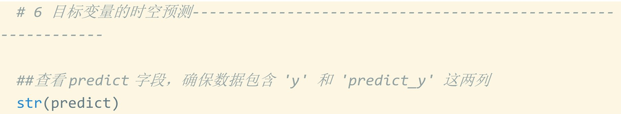

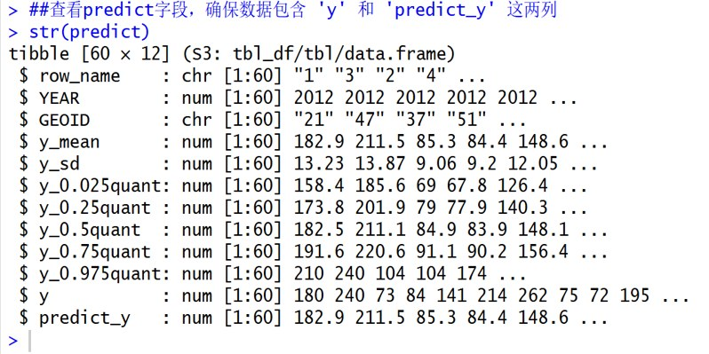

2）评估指标计算与散点图可视化

对于计数型目标变量Y，若模型预测结果已回到原始计数尺度，则可基于观测值与预测均值绘制散点图，并计算MAE、Mean Poisson Deviance等预测精度指标。

**①MAE（平均绝对误差）：**表示模型平均预测错了多少个单位

**②Mean Poisson Deviance（平均偏差）：**模型预测的计数分布，与真实计数之间平均偏离多少

注：尽管本案例没有缺失数据，此处只是做示例处理若有缺失数据的情况

```
predict_clean <- predict %>%
filter(!is.na(y), !is.na(predict_y)) %>%
mutate(
y = as.numeric(y),
predict_y = pmax(as.numeric(predict_y), 1e-8)
)
## 泊松型预测评价指标
poisson_deviance <- function(y, mu) {

2 * sum(ifelse(y == 0, 0, y * log(y / mu)) - (y - mu))

}
MAE <- mean(abs(predict_clean$y - predict_clean$predict_y))
model_deviance <- poisson_deviance(
y = predict_clean$y,
mu = predict_clean$predict_y
)
Mean_Poisson_Deviance <- model_deviance / nrow(predict_clean)
null_mu <- mean(predict_clean$y)
null_deviance <- poisson_deviance(
y = predict_clean$y,
mu = rep(null_mu, nrow(predict_clean))
)
Deviance_R2 <- 1 - model_deviance / null_deviance
label_text <- paste0(
"MAE = ", round(MAE, 4),

"\nMean Poisson dev. = ", round(Mean_Poisson_Deviance, 4)

)
## 打印结果
print(paste("MAE:", round(MAE, 4)))
print(paste("Mean Poisson Deviance:", round(Mean_Poisson_Deviance, 4)))
print(paste("Deviance R²:", round(Deviance_R2, 4)))
```

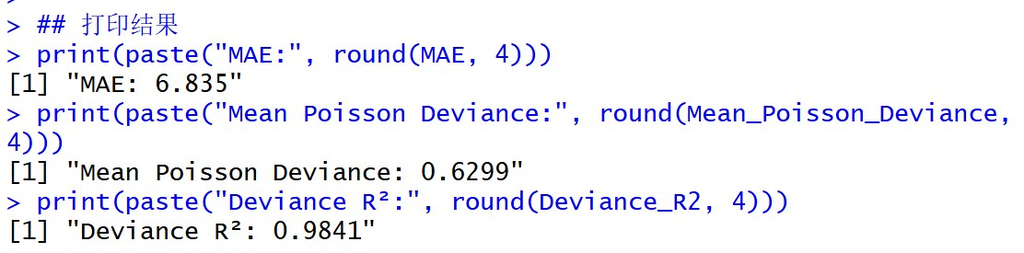

```
## 绘制预测散点图
p6 <- ggplot(predict_clean, aes(x = y, y = predict_y)) +
geom_abline(
slope = 1,
intercept = 0,
color = "red",
linewidth = 1,
linetype = "dashed"

) +

geom_point(aes(fill = y), size = 2.5, shape = 22, color = "white") +
annotate(
"text",
x = Inf,
y = -Inf,
label = label_text,
hjust = 1.05,
vjust = -0.35,
family = "serif",
fontface = "bold",
size = 4.5

) +

scale_fill_gradient(low = "#88d8db", high = "#b8aeeb") +
labs(
x = "Measured Values",
y = "Predicted Values"

) +

theme_few() +
theme(
text = element_text(family = "serif", face = "bold"),
axis.text = element_text(family = "serif", size = 12, face = "bold"),
axis.title = element_text(size = 12),
legend.position = "none"
)

p6

#保存图片结果
ggsave(
"predict_point.png",
p6,
width = 12,
height = 8,
dpi = 300
)
```

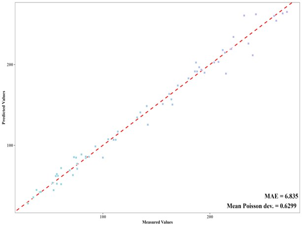

3）预测后的Y的时空分面可视化地图

```
## 预测后的 Y 的时空分面可视化地图
#观察数据结构 便于绘制

names(predict)
class(predict)
head(predict)
names(us_a5)
class(us_a5)
head(us_a5)

predict_map <- us_a5 %>%
mutate(GEOID = as.character(GEOID)) %>%
left_join(
predict %>%
mutate(GEOID = as.character(GEOID)),
by = "GEOID"
)
## 预测后的 Y 的时空分面可视化地图，本例设置为4列3行
p7 <- ggplot(predict_map) +
geom_sf(aes(fill = predict_y), color = "white", linewidth = 0.25) +
facet_wrap(~ YEAR, ncol = 4) +
scale_fill_gradient(
low = "#88d8db",
high = "#b8aeeb",
na.value = "grey90",
name = "预测值"

) +

scale_x_continuous(
breaks = seq(-90, -75, by = 5),
labels = function(x) paste0(abs(x), "°W")

) +

scale_y_continuous(
breaks = seq(34, 41, by = 2),
labels = function(y) paste0(y, "°N")

) +

coord_sf(
xlim = c(-91, -74),
ylim = c(33.5, 41),
expand = FALSE

) +

labs(
title = NULL,
x = "经度",
y = "纬度"

) +

theme_few() +
theme(
text = element_text(family = "serif", face = "bold"),
axis.text = element_text(size = 7, color = "black"),
axis.title = element_text(size = 10, face = "bold"),
axis.ticks = element_line(color = "grey40", linewidth = 0.25),
panel.grid.major = element_line(color = "grey85", linewidth = 0.25),
panel.border = element_rect(color = "grey35", fill = NA, linewidth = 0.4),
strip.text = element_text(size = 10, face = "bold"),
legend.title = element_text(size = 10, face = "bold"),
legend.text = element_text(size = 8),
legend.position = "right"
)

p7

ggsave(
filename = "p7_predict_time_map.png",
plot = p7,
width = 12,
height = 8,
dpi = 300
)
```

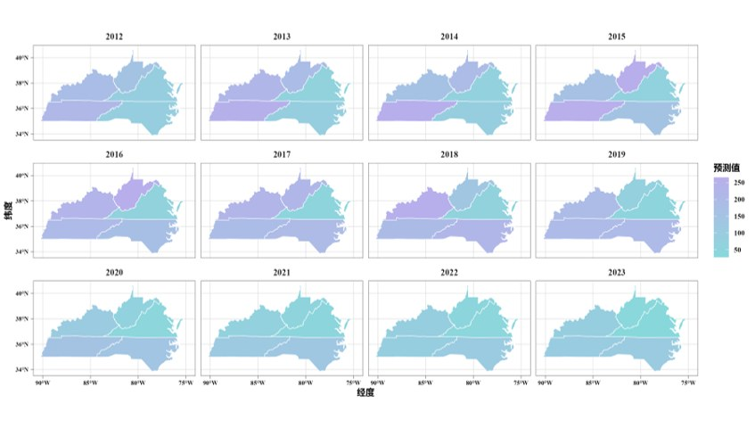